# Supervised Learning - Foundations Project: ReCell

### Device Weight Distribution for Large Battery Devices (>4500 mAh)

- Out of the full dataset, **341 devices** offer a battery capacity greater than 4500 mAh.
- The **red line** represents the **median weight** of these high-capacity battery devices.
- The **black dashed line** represents the **overall dataset's median weight**.
- Devices with larger batteries clearly trend toward **higher weight**, as shown by the shift in the red line to the right.
- This supports the common trade-off in mobile devices: **higher battery capacity often leads to reduced portability** due to increased weight.
- For frequent travelers or users on the go, this trade-off must be considered — performance vs. comfort.

```
Number of devices with screen size > 6 inches: 3362
```

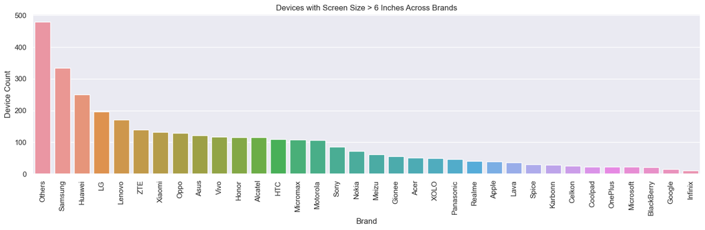

```python
# Filter devices with screen size > 6 inches
entertainment_df = df[df["screen_size"] > 6]

# Print count of such devices
print(f"Number of devices with screen size > 6 inches: {entertainment_df.shape[0]}")

# Plot distribution across brands
plt.figure(figsize=(15, 5))
sns.countplot(data=entertainment_df, x="brand_name", order=entertainment_df["brand_name"].value_counts().index)
plt.xticks(rotation=90)
plt.title("Devices with Screen Size > 6 Inches Across Brands")
plt.xlabel("Brand")
plt.ylabel("Device Count")
plt.tight_layout()
plt.show()
```

### Devices with Screen Size > 6 Inches (Entertainment-Oriented Devices)

- A total of **3362 devices** in the dataset offer a screen size larger than 6 inches, making them ideal for entertainment use such as streaming, gaming, and media consumption.
- **Others**, **Samsung**, **Huawei**, and **LG** lead the market for large-screen devices, following the 'Others' category which includes various lesser-known or mixed-brand entries.
- Other notable contributors include **Lenovo**, **ZTE**, **Xiaomi**, **Oppo**, and **Vivo**, showing strong brand diversification in this space.
- The wide spread across brands indicates that large-screen devices are offered across both budget and premium segments.
- This segmentation is helpful for marketing and product positioning strategies — especially when targeting users prioritizing visual experiences.

```python
df_large_screen = df[df.screen_size > 6 * 2.54]
df_large_screen.shape
```

```
(1099, 15)
```

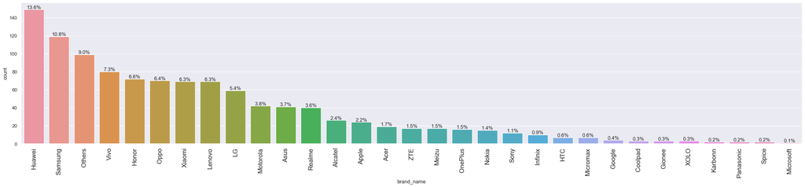

```python
labeled_barplot(df_large_screen, "brand_name", perc=True)
```

### Brand Distribution Among Devices with Screen Size > 6 Inches

- A total of **1,099 devices** in the filtered dataset feature screen sizes greater than 6 inches, catering to users seeking enhanced media and entertainment experiences.
- **Huawei (13.6%)** and **Samsung (10.8%)** and **Others (9.0%)** dominate this segment, indicating their strong positioning in the large-screen market.
- The **‘Others’** category (9%) represents a mix of lesser-known or diverse brands that collectively make a significant contribution.
- Brands such as **Vivo (7.3%)**, **Honor (6.6%)**, **Oppo (6.4%)**, and **Xiaomi (6.3%)** show solid participation, suggesting a competitive mid-tier market.
- **Apple (2.2%)** and **OnePlus (1.5%)**, though present, contribute less to this segment—possibly due to more premium or compact device positioning.
- The wide spread of brands with large-screen devices reflects both **budget and premium offerings**, providing insights for price-tier segmentation and marketing strategy.
- This distribution is useful for targeting **content consumers, gamers, and productivity users**, who typically favor larger displays for a better experience.

**Everyone likes a good camera to capture their favorite moments with loved ones. Some customers specifically look for good front cameras to click cool selfies. Let's create a new dataframe of only those devices which are suitable for this customer segment and analyze.**

```python
df_selfie_camera = df[df.selfie_camera_mp > 8]
df_selfie_camera.shape
```

```
(655, 15)
```

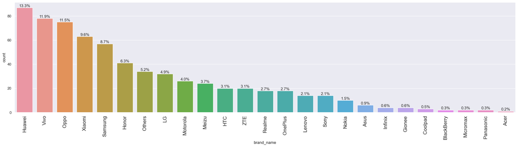

```python
labeled_barplot(df_selfie_camera, "brand_name", perc=True)
```

### Devices with Front Camera > 8 MP (Selfie-Oriented Devices)

- A total of **655 devices** in the dataset feature a selfie camera resolution greater than 8 MP, targeting users who prioritize high-quality front-facing photos.
- **Huawei**, **Vivo**, and **Oppo** lead this category, collectively accounting for over a third of all selfie-focused devices—highlighting their market emphasis on photography-centric features.
- **Xiaomi** and **Samsung** follow closely, offering a broad range of devices with high-resolution front cameras, appealing to both budget and premium buyers.
- Other contributors include **Honor**, **LG**, and **Motorola**, reflecting a balanced distribution of selfie capabilities across mid-tier brands.
- This segmentation is highly useful for **influencer-targeted campaigns**, **youth-oriented marketing**, and for identifying brands that **invest heavily in camera features**.

**Let's do a similar analysis for rear cameras.**

Rear cameras generally have a better resolution than front cameras, so we set the threshold higher for them at 16MP.

```python
df_main_camera = df[df.main_camera_mp > 16]
df_main_camera.shape
```

```
(94, 15)
```

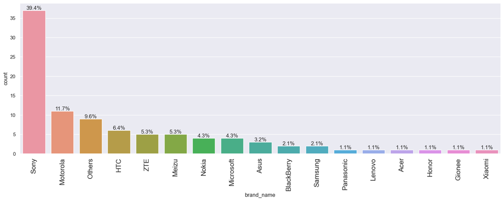

```python
labeled_barplot(df_main_camera, "brand_name", perc=True)
```